# Outbreaks Dx readiness index progress report

Anna Mantsoki

23/04/2024

## Why we build the Diagnostic readiness index (DxRI) for pathogens of Outbreak potential?

The **Pandemics Threat (PT) team** at FIND initiated the project being inspired by other available indexes such as:

- [**The Global Health Security index (GHS)**](https://ghsindex.org/)
- [**100 Days Mission Scorecard**](https://d7npznmd5zvwd.cloudfront.net/prod/uploads/2024/01/100-Days-Mission-Scorecard-Report.pdf)

The **goal of the Dx readiness index for pathogens of Outbreak potential** is to highlight:

1. *The availability of diagnostic tools in global scale*
2. *Raise awareness for current gaps in the diagnostic technology landscape across diseases*
3. *Guide investements for future development of diagnostic tools*

### Methodology

#### Data sources and processing

The raw data used to build the index come from the [**Test Directory database**](https://find.lightning.force.com/lightning/r/Report/00OVj0000003Xc9MAE/view?queryScope=userFolders), captured by the **Business Intelligence (BI) team** at FIND.

We have included data from technology landscapes for **21 pathogens of Outbreak potential, corresponding to 19 diseases** as shown below.

| pathogen | disease_target | last_update |
| --- | --- | --- |
| Chikungunya Virus | Chikungunya | 2018 |
| Zika Virus | Zika Fever | 2019 |
| Sars-Cov-2 | Covid-19 | 2021 |
| Crimean Congo Hemorrhagic Fever Virus | Crimean Congo Hemorrhagic Fever | 2021 |
| Dengue Virus | Dengue Fever | 2021 |
| Ebola Virus | Ebola Fever | 2022 |
| Mpox Virus | Mpox | 2022 |
| Vibrio Cholerae | Cholera | 2023 |
| Lassa Virus | Lassa Fever | 2023 |
| Marburg Virus | Marburg | 2023 |

[output cut: 11 more lines]

|  | pathogen | disease_target | last_update |
| --- | --- | --- | --- |
| 1 | Chikungunya Virus | Chikungunya | 2018 |
| 2 | Zika Virus | Zika Fever | 2019 |
| 3 | Sars-Cov-2 | Covid-19 | 2021 |
| 4 | Crimean Congo Hemorrhagic Fever Virus | Crimean Congo Hemorrhagic Fever | 2021 |
| 5 | Dengue Virus | Dengue Fever | 2021 |
| 6 | Ebola Virus | Ebola Fever | 2022 |
| 7 | Mpox Virus | Mpox | 2022 |
| 8 | Vibrio Cholerae | Cholera | 2023 |
| 9 | Lassa Virus | Lassa Fever | 2023 |
| 10 | Marburg Virus | Marburg | 2023 |

[output cut: 11 more lines]

Below you see a summary table for the indicators we have included and how we generated the score for each of them.

| IndName | IndCode | Description of metric | Method used to transform source metric | Indicator or grouping variable | Comment |
| --- | --- | --- | --- | --- | --- |
| Planned market entry | planned_market_entry | • Is there a commercially available test, yes/no? | Variable – planned_market_entry o Score by summing up the numbers by pathogen ➢ 1 – yes ➢ 0 – no | Indicator | NA |
| Regulatory approval | reg_approval | • Is there a regulatory-approved test, yes/no? | Variable – stage_of_development o Score by summing up the numbers by pathogen ➢ 1 – yes (Regulatory Achieved) ➢ 0 – no (in development OR regulatory unknown OR no info) | Indicator | Should we remove this variable because it is correlated with the Regulatory status variable? Shuold we add instead a stage of development variable to also count active development of assays for each p… |
| Regulatory status | reg_status | • Is it approved by any IMDRF agency? | Variable – regulatory_status o Score by summing up the numbers by pathogen ➢ 1 – yes (if any listed in IMDRF, e.g. US FDA, Brazil ANVISA, CE-IVDR, WHO EUL/EUA) ➢ 0 – no (if non, Other, Unknown or CE-I… | Indicator | What is the case of Regulatory achieved but no agency shows up in the field of regulatory_status? |
| Reference lab available | ref_lab | • Is there a test available for: o Reference lab? | Variable – lab_vs_poc o Score sum of Lab based = 1 ➢ 1 – yes ➢ 0 – no | Indicator | NA |
| Hospital lab available | hosp_lab | • Is there a test available for: o Hospital lab? | Variable: lab_vs_poc o Score sum of near Point of Care OR true Point of Care = 1 ➢ 1 – yes ➢ 0 – no | Indicator | Should we remove the true point of care because it is counted in phc variable? |
| Primary health care available | phc | • Is there a test available for: o Primary care? | Variable – lab_vs_poc o Score sum of true Point of Care = 1 ➢ 1 – yes ➢ 0 – no | Indicator | NA |
| TPP available | tpp_available | • Is there a diagnostic TPP available? | Variable – TPP available per disease_target o Dataset – manually curated list o Score binary ➢ 1 – yes ➢ 0 – no | Indicator | NA |
| Disease | disease_target | List of WHO R&D Blueprint pathogens, list of emerging infectious diseases by WHO : "Chikungunya Virus", "Crimean Congo Hemorrhagic Fever Virus", "Dengue Virus", "Ebola Virus", "Influenza A", "Influenz… | Variable = disease_target | Grouping variable | NA |
| Transmission mode | transmission_mode | "Airborne droplets, Contact", "Contact", "Food/waterborne", "Respiratory", "Vector-borne", "Vertical", "Waterborne", "Zoonotic" | Manually curated list | Grouping variable | NA |

|  | IndName | IndCode | Description of metric | Method used to transform source metric | Indicator or grouping variable | Comment |
| --- | --- | --- | --- | --- | --- | --- |
| 1 | Planned market entry | planned_market_entry | • Is there a commercially available test, yes/no? | Variable – planned_market_entry o Score by summing up the numbers by pathogen ➢ 1 – yes ➢ 0 – no | Indicator |  |
| 2 | Regulatory approval | reg_approval | • Is there a regulatory-approved test, yes/no? | Variable – stage_of_development o Score by summing up the numbers by pathogen ➢ 1 – yes (Regulatory Achieved) ➢ 0 – no (in development OR regulatory unknown OR no info) | Indicator | Should we remove this variable because it is correlated with the Regulatory status variable? Shuold we add instead a stage of development variable to also count active development of assays for each p… |
| 3 | Regulatory status | reg_status | • Is it approved by any IMDRF agency? | Variable – regulatory_status o Score by summing up the numbers by pathogen ➢ 1 – yes (if any listed in IMDRF, e.g. US FDA, Brazil ANVISA, CE-IVDR, WHO EUL/EUA) ➢ 0 – no (if non, Other, Unknown or CE-I… | Indicator | What is the case of Regulatory achieved but no agency shows up in the field of regulatory_status? |
| 4 | Reference lab available | ref_lab | • Is there a test available for: o Reference lab? | Variable – lab_vs_poc o Score sum of Lab based = 1 ➢ 1 – yes ➢ 0 – no | Indicator |  |
| 5 | Hospital lab available | hosp_lab | • Is there a test available for: o Hospital lab? | Variable: lab_vs_poc o Score sum of near Point of Care OR true Point of Care = 1 ➢ 1 – yes ➢ 0 – no | Indicator | Should we remove the true point of care because it is counted in phc variable? |
| 6 | Primary health care available | phc | • Is there a test available for: o Primary care? | Variable – lab_vs_poc o Score sum of true Point of Care = 1 ➢ 1 – yes ➢ 0 – no | Indicator |  |
| 7 | TPP available | tpp_available | • Is there a diagnostic TPP available? | Variable – TPP available per disease_target o Dataset – manually curated list o Score binary ➢ 1 – yes ➢ 0 – no | Indicator |  |
| 8 | Disease | disease_target | List of WHO R&amp;D Blueprint pathogens, list of emerging infectious diseases by WHO : "Chikungunya Virus", "Crimean Congo Hemorrhagic Fever Virus", "Dengue Virus", "Ebola Virus", "Influenza A", "Infl… | Variable = disease_target | Grouping variable |  |
| 9 | Transmission mode | transmission_mode | "Airborne droplets, Contact", "Contact", "Food/waterborne", "Respiratory", "Vector-borne", "Vertical", "Waterborne", "Zoonotic" | Manually curated list | Grouping variable |  |

#### Composite index framework

Composite indexes are generated by combining multiple individual indicators into a single measure. A composite indicator may include several dimensions, where the dimensions represent different domains or aspects of the phenomenon being measured. Examples of common composite indices are index of well-being, sustainable development, economic growth etc. We build the Dx readiness index (DxRI) using a composite indicator framework, in an effort to summarize and present the key variables that form a diagnostic technology landscape.

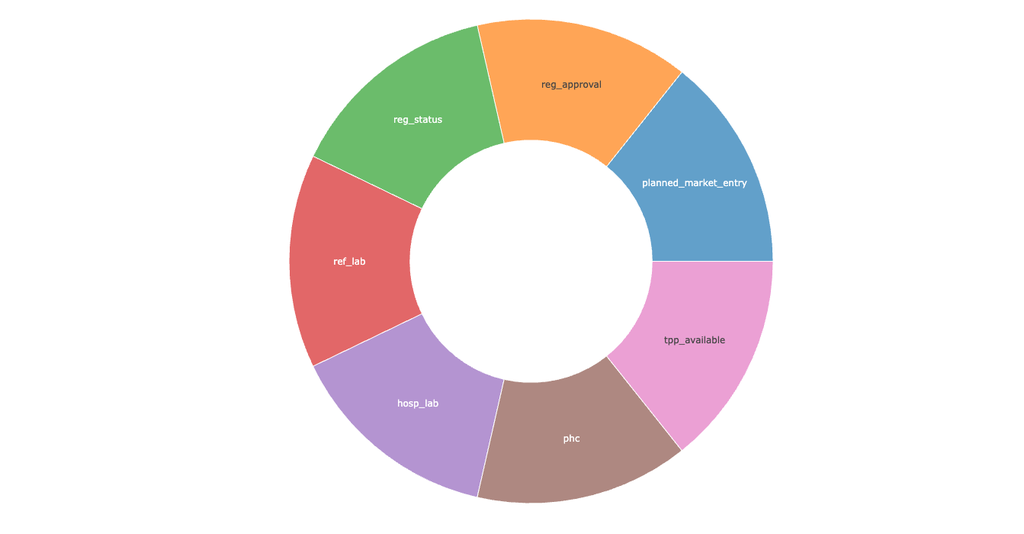

#### Building a composite indicator live

We will use the [composer](https://shinyproxy.finddx.org/app/composer?sp_hide_navbar=true) application we have developed at FIND.

## Results

| Pathogen | Disease | Transmission mode | Rank | DxRI | Reg. achieved | Reg. authorities | Planned market entry | Available in ref. lab | Available in hosp. lab | Available in primary health clinic | Available TPP | Reg. achieved | Reg. authorities | Planned market entry | Available in ref. lab | Available in hosp. lab | Available in primary health clinic | TPP available |
| --- | --- | --- | --- | --- | --- | --- | --- | --- | --- | --- | --- | --- | --- | --- | --- | --- | --- | --- |
| Sars-Cov-2 | Covid-19 | Respiratory | 1 | 19.43 | 20 | 20 | 20 | 20 | 20 | 20 | 16 | 2078 | 1548 | 2616 | 949 | 1455 | 1201 | 1 |
| Dengue Virus | Dengue Fever | Vector-borne | 2 | 15.86 | 19 | 16 | 19 | 19 | 19 | 19 | 0 | 216 | 30 | 454 | 179 | 286 | 260 | 0 |
| Influenza A | Influenza | Respiratory | 3 | 14.29 | 18 | 18 | 18 | 12 | 17 | 17 | 0 | 214 | 175 | 216 | 64 | 150 | 112 | 0 |
| Influenza B | Influenza | Respiratory | 4 | 14 | 17 | 18 | 17 | 12 | 17 | 17 | 0 | 213 | 175 | 215 | 64 | 150 | 112 | 0 |
| Rubella Virus | Rubella | Respiratory | 5 | 13.71 | 15 | 17 | 16 | 18 | 15 | 15 | 0 | 76 | 53 | 199 | 128 | 71 | 70 | 0 |
| Vibrio Cholerae | Cholera | Waterborne | 6 | 13.43 | 13 | 14 | 13 | 10 | 14 | 14 | 16 | 65 | 18 | 105 | 50 | 55 | 40 | 1 |
| Mpox Virus | Mpox | Contact; Zoonotic | 7 | 12.71 | 16 | 11 | 6 | 16 | 13 | 11 | 16 | 94 | 10 | 44 | 93 | 39 | 14 | 1 |
| Yellow Fever Virus | Yellow Fever | Vector-borne | 8 | 11 | 9 | 12 | 11 | 14 | 7 | 8 | 16 | 36 | 11 | 74 | 65 | 12 | 8 | 1 |
| Salmonella Typhi | Typhoid Fever | Food/waterborne | 9 | 10.43 | 14 | 9 | 15 | 3 | 16 | 16 | 0 | 72 | 8 | 139 | 20 | 121 | 97 | 0 |
| Ebola Virus | Ebola Fever | Contact; Zoonotic | 10 | 9.43 | 7 | 15 | 10 | 11 | 11 | 12 | 0 | 28 | 20 | 73 | 56 | 25 | 16 | 0 |

[output cut: 11 more lines]

#### Questions regarding methodology and results

- Including COVID-19 in the framework, might create a false target for the other pathogens.
- Why are there cases where there is Regulatory achieved in the Stage of development, but no regulatory agency is captured? This is a question of data integrity checks at the level of the database. If we believe we can based an index to this dataset, then we should be absolutely sure the data is reflecting an up to date landscape.
- Regulatory achieved (reg_approval) and Number of regulatory authorities (reg_status) should not be present in the framework at the same time, we should make a decision which ones is more accurate and keep that.
- Should we consider adding an indicator reflecting the current number of tests under development? The idea is that if there are tests already under development, they could easier move in the product development phase with the right amount of investment. We could include the tests that are 1. Research use only, 2. Development, 3. Late Stage Development, 4. Validation, 5. Early Stage Development (partial prototype)
- Should we consider including an indicator to reflect the severity of the disease (i.e. mortality rate)?
- We should check if our index correlates with the total amount of funding per pathogen (100 Days mission) as a validation, but we should not include it in the generation of the index.

## Limitations

- Limited options in terms of publicly available data to include for future development, we need a concerted effort to have a full landscape of data availability
- What is the different offering and innovative feature of DxRI?
- Internal delays for contracting partners/consultants to conduct landscapes, build website

## Next steps

- Conduct a data availability landscape for pathogen specific data per country (to assess feasibility of Phase 2 below)
  - capture availability of data on disease burden
  - capture number of countries with availability of data on readiness and type of readiness data
- Development of website with [onetandem](https://www.onetandem.com/)
  - Phase 1: showcase the DxRI with each pathogen as an entry point, highlight the diagnostic landscape needs/gaps
  - Phase 2: include country specific data when available. Still the entry point should be each pathogen, and only relevant countries (i.e. countries with recorded outbreaks) should be included in a separate framework of readiness. Otherwise if we try to show readiness per country, it will not be representative of the situation, where not all pathogens are present across all countries.